# Язычки и моря

Вадим Хайтов

17 января 2019 г

Коллеги, извините, но мне проще сформулировать вопросы для себя и решить это так как я бы стал это делать. Поэтому, смотрите и решайте, может быть надо все иначе делать, можете переубедить меня, если получится.

Итак, я вижу задачу следующим образом.

## Постановка вопроса

Что мы знаем после исследований в Белом море?

1.Частота морфотипов коррелирует с генетическим статусом: среди M.trossulus большинство являются T-морфотипом, среди ME - большинство E-морфотипом.

2.Чем выше частота MT в популяции, тем больше доля T-морфотипа.

3.Чем больше размер мидии, тем ниже вероятность встретить T-морфотип

4.MT, а стало быть и T-морфотип, чаще встречаются в опресненных местообитаниях.

5.Доля MT (а стало быть и частота T- морфотипа) выше на талломах водорослей, чем на грунте в данной точке. В данном документе я пока не буду решать эту проблему, а сосредоточусь только на пп. 1-4.

Главный вопрос: будут ли наблюдаться аналогичные зависимости в Баренцевом море.

# Как выглядят ответы на эти вопросы.

## Вопрос 1.

Частота морфотипов коррелирует с генетическим статусом: среди M.trossulus большинство являются T-морфотипом, среди ME - большинство E-морфотпом.

**Если в Баренцевом море все так же, как в Белом**

1. Между факторами Sp и sea нет взаимодействия.
2. В двух морях частота T-морфотипа выше среди MT, чем среди ME.
3. В двух морях большинство MT (более 50%) имеют T-морфотип

**Если в Баренцевом море все не так, как в Белом**

1. Между факторами Sp и sea есть значимое взаимодействия.
2. В двух морях частота T-морфотипа выше среди MT, чем среди ME.
3. В двух морях большинство MT (более 50%) имеют T-морфотип

## Вопрос 2.

Чем выше частота MT в популяции, тем больше доля T-морфотипа.

**Если в Баренцевом море все так же, как в Белом**

Между факторами freq_MT и sea нет взаимодействия.

**Если в Баренцевом море все не так, как в Белом**

Между факторами freq_MT и sea есть значимое взаимодействия.

## Вопрос 3.

Чем больше размер мидии, тем ниже вероятность встретить T-морфотип

**Если в Баренцевом море все так же, как в Белом**

Между факторами size и sea нет взаимодействия.

**Если в Баренцевом море все не так, как в Белом**

Между факторами size и sea есть значимое взаимодействия.

## Вопрос 4.

MT, а стало быть и T-морфотип, чаще встречаются в опресненных местообитаниях.

**Если в Баренцевом море все так же, как в Белом**

Между факторами sal_place и sea нет взаимодействия.

**Если в Баренцевом море все не так, как в Белом**

Между факторами sal_place и sea есть значимое взаимодействия.

## Читаем и подготавливаем данные

```r
library(lme4)
```

```r
library(ggplot2)
library(reshape2)
library(sjstats)
library(dplyr)
library(car)
myt <- read.table("data_salinity2.csv", header = T, sep = ",")

myt$Sp [myt$str > 0.5] <- "M.trossulus" #Лучше обозначать так!
myt$Sp [myt$str <= 0.5] <- "M.edulis"
myt$Sp <- factor(myt$Sp)


myt$sal_place <- factor(myt$sal_place, levels = c("low", "meadle", "high"))
myt$sal_place2 <- ifelse(myt$sal_place == "low", "fresh", "normal")
```

Поскольку я полагаю, что выделение большого количества градаций солености от лукавого, то предлагаю упростить анализ, введя только две градации солености `"fresh"` (находится в устье какого-то источника опреснения, то что при у вас названо `"low"`) и “normal” (все остальное).

Далее, в датасете есть пропуски измерений.

```r
colSums(is.na(myt))
```

```
##               sea             place         sal_place         sal_graph
##                 0                 0                 0                40
##       place_tyuva          standart               pop      pop.for.dist
##                 0                 0                 0               756
##           pop_sub         substrate          horizont              year
##               860               860                 0               493
##               str              size               age               ind
##                 0                30               504                32
##           freq_MT freq_MT_substrate              dist           sal_low
##                 0               860               756                 0
##                Sp        sal_place2
##                 0                 0
```

```r
# 30 мидий не имеют размеров. Удаляем их из датасета

myt2 <- myt[!is.na(myt$size), ]


colSums(is.na(myt2))
```

```
##               sea             place         sal_place         sal_graph
##                 0                 0                 0                40
##       place_tyuva          standart               pop      pop.for.dist
##                 0                 0                 0               726
##           pop_sub         substrate          horizont              year
##               830               830                 0               463
##               str              size               age               ind
##                 0                 0               474                14
##           freq_MT freq_MT_substrate              dist           sal_low
##                 0               830               726                 0
##                Sp        sal_place2
##                 0                 0
```

```r
# 14 мидий не имеют измерений язычка. Сломаны чтоли? Удаляем их датасета.

myt2 <- myt2[!is.na(myt2$ind), ]
```

Далее работаем с датасетом `myt2`

## Модель

На основе поставленных вопросов строим модель. В этой модели есть следующие части

ind - зависимая переменная

Предикторы в фиксированной части модели

sea - море  
Sp - генетически определенный вид size - размер freq_MT - частота MT в популяции

pop - популяция, случайный фактор.

Поскольку ключевой, с моей точки зрения, вопрос - это вопрос о связи с морем, то не вижу необходимости моделировать сложные взаимодействия предиктров. В связи с этим модель выглядит вот так.

```r
Mod <- glmer(ind ~ Sp + sea + size + sal_place2 + freq_MT +  Sp:sea + size:sea + sal_place2:sea + freq_MT:sea + (1 | sea:pop), data = myt2, family = "binomial", control=glmerControl(optimizer="bobyqa",optCtrl=list(maxfun=2e5)))
```

Поверяем на избыточную дисперсию

```r
overdisp(Mod)
```

```
##
## # Overdispersion test
##
##        dispersion ratio = 0.9006
##   Pearson's Chi-Squared = 1592.2132
##                 p-value = 0.9989
```

```
## No overdispersion detected.
```

Все OK.

Упрощаем модель

```r
drop1(Mod)
```

```
## Single term deletions
##
## Model:
## ind ~ Sp + sea + size + sal_place2 + freq_MT + Sp:sea + size:sea +
##     sal_place2:sea + freq_MT:sea + (1 | sea:pop)
##                Df    AIC
## <none>            1629.5
## Sp:sea          1 1636.2
## sea:size        1 1648.8
## sea:sal_place2  1 1636.7
## sea:freq_MT     1 1627.5
```

```r
Mod2 <- update(Mod, . ~. -sea:freq_MT )

drop1(Mod2)
```

```
## Single term deletions
##
## Model:
## ind ~ Sp + sea + size + sal_place2 + freq_MT + (1 | sea:pop) +
##     Sp:sea + sea:size + sea:sal_place2
##                Df    AIC
## <none>            1627.5
## freq_MT         1 1636.6
## Sp:sea          1 1634.3
## sea:size        1 1646.8
## sea:sal_place2  1 1637.8
```

Больше ничего не выкинуть.

Проверяем финальную модель на сверхдисперсию

```r
overdisp(Mod2)
```

```
##
## # Overdispersion test
##
##        dispersion ratio = 0.8990
##   Pearson's Chi-Squared = 1590.4043
##                 p-value = 0.9990
```

```
## No overdispersion detected.
```

Все ОК.

## Диагностика финальной модели

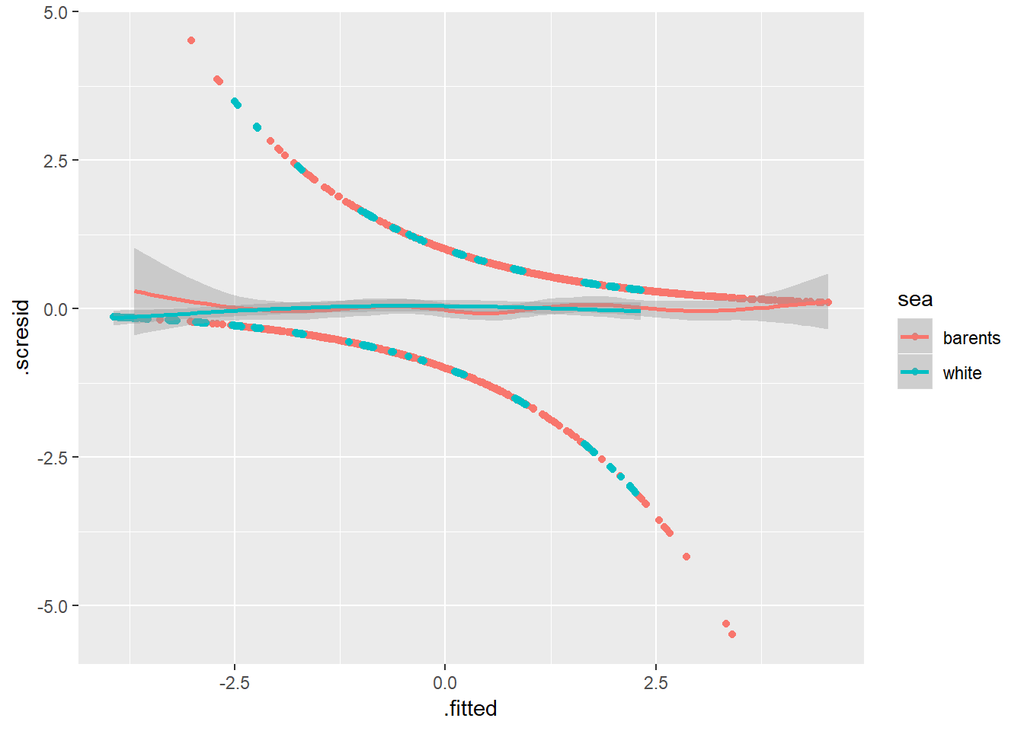

```r
Mod2_diagn <- fortify(Mod2)

ggplot(Mod2_diagn, aes(x = .fitted, y = .scresid, color = sea)) + geom_point() + geom_smooth()
```

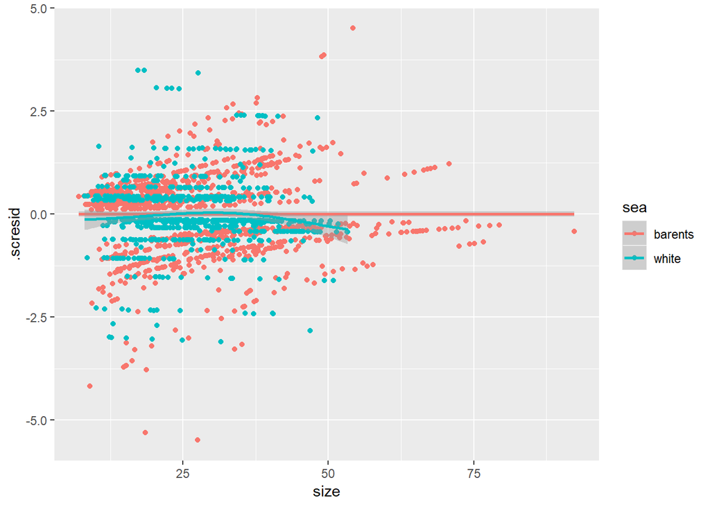

```r
# здес все ОК


ggplot(Mod2_diagn, aes(x = size, y = .scresid, color = sea)) + geom_point() + geom_smooth()
```

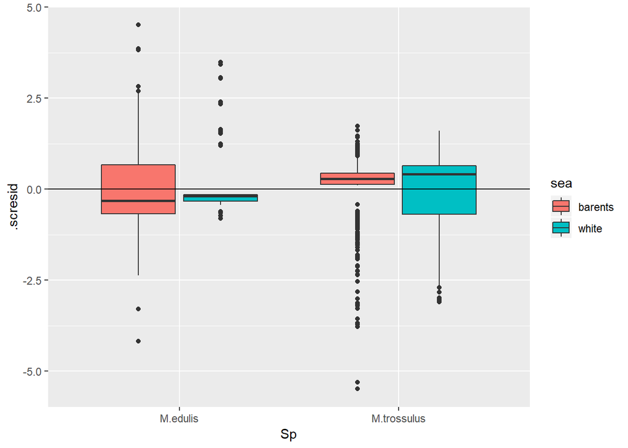

```r
# здес все ОК




ggplot(Mod2_diagn, aes(x = Sp, y = .scresid, fill = sea)) + geom_boxplot() + geom_hline(yintercept = 0)
```

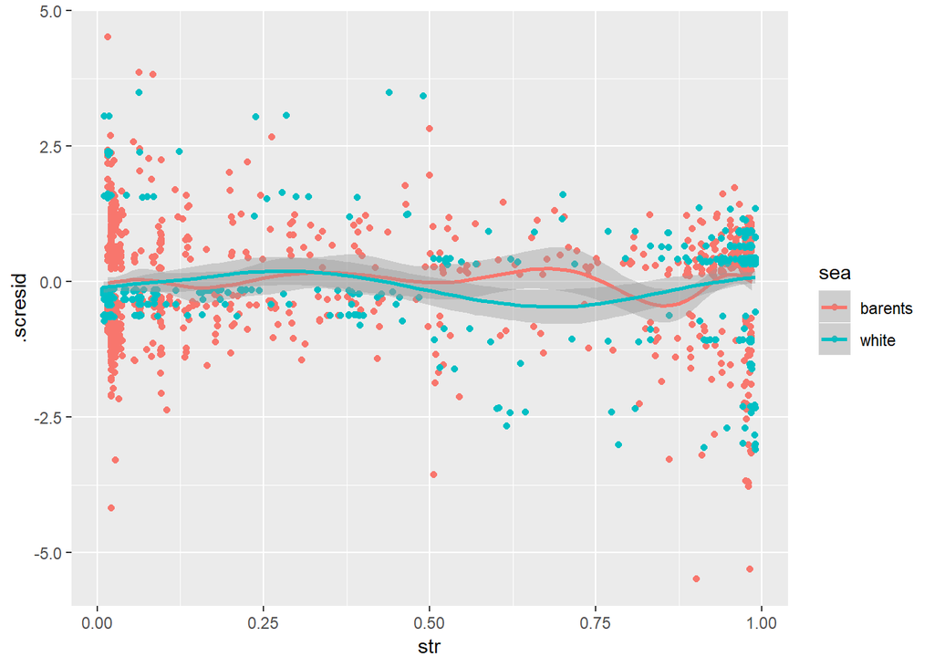

```r
#Не очень...

# А вот в терминах str
ggplot(Mod2_diagn, aes(x = str, y = .scresid, color = sea)) + geom_point() + geom_smooth()
```

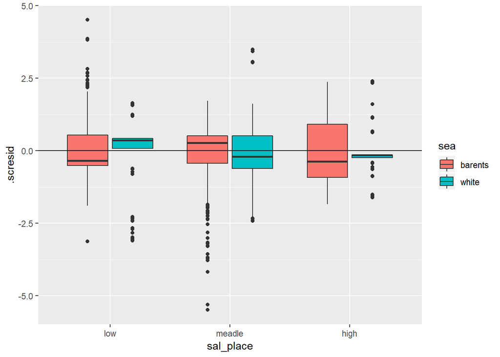

```r
#Бывает и хуже... Короче, на это можно забить.



ggplot(Mod2_diagn, aes(x = sal_place, y = .scresid, fill = sea)) + geom_boxplot() + geom_hline(yintercept = 0)
```

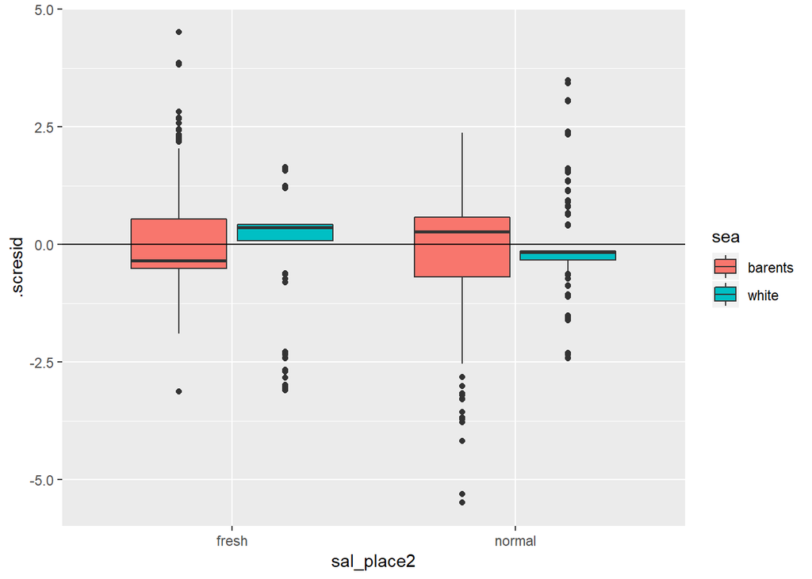

```r
ggplot(Mod2_diagn, aes(x = sal_place2, y = .scresid, fill = sea)) + geom_boxplot() + geom_hline(yintercept = 0)
```

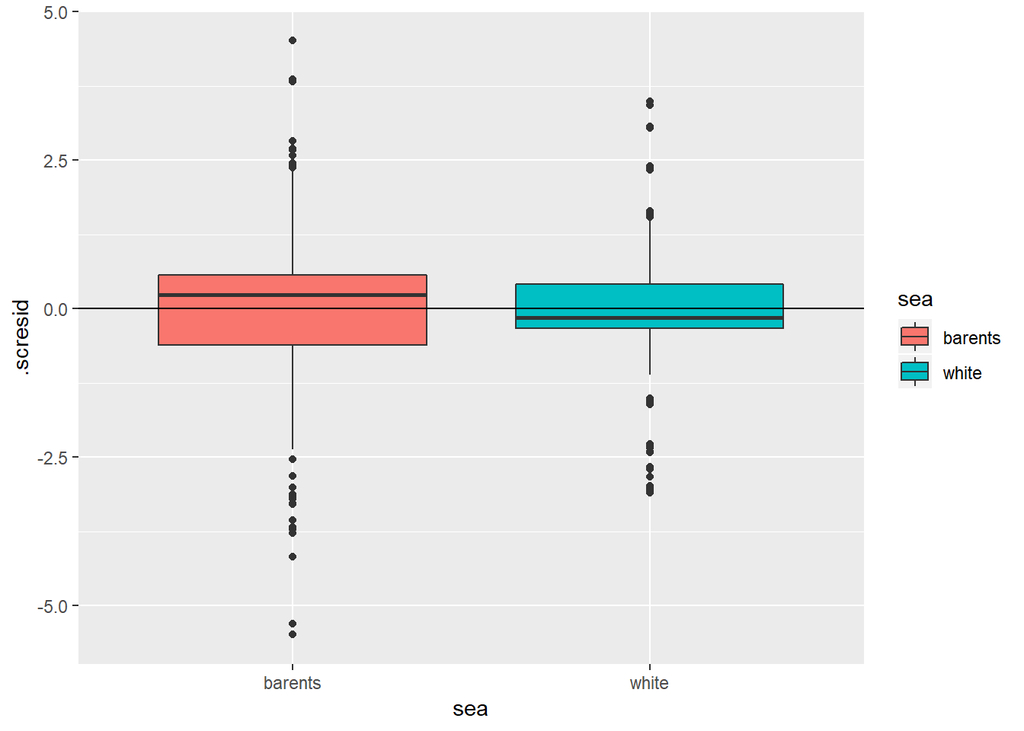

```r
#Не очень... Бывает и хуже... Короче, на это можно забить.

ggplot(Mod2_diagn, aes(x = sea, y = .scresid, fill = sea)) + geom_boxplot() + geom_hline(yintercept = 0)
```

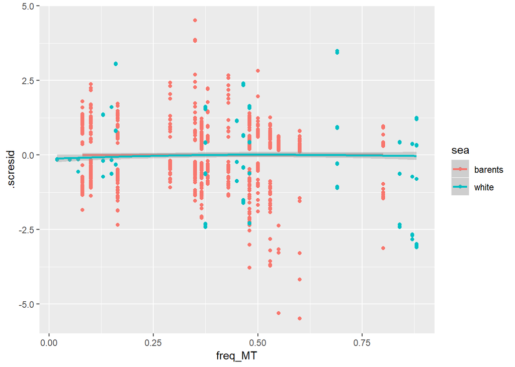

```r
# ОК


ggplot(Mod2_diagn, aes(x = freq_MT, y = .scresid, color = sea)) + geom_point() + geom_smooth()
```

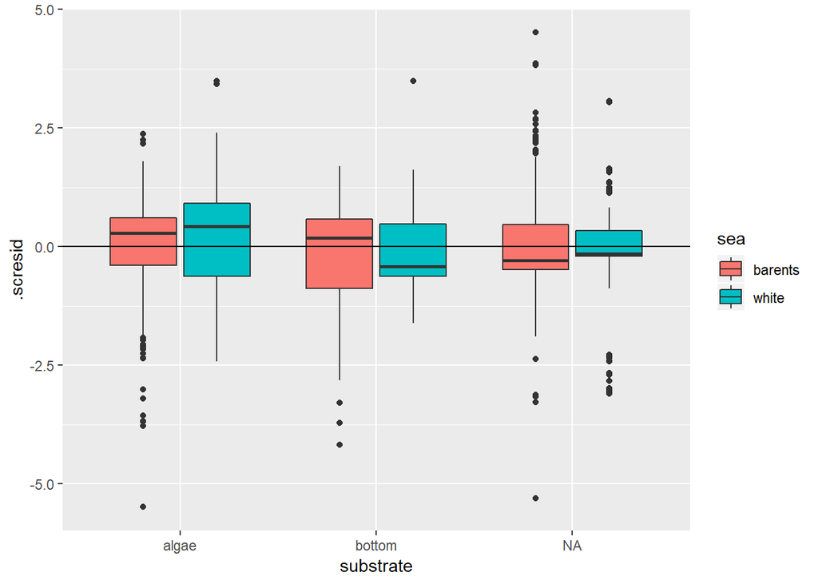

```r
# Безупречно

ggplot(Mod2_diagn, aes(x = substrate, y = .scresid, fill = sea)) + geom_boxplot() + geom_hline(yintercept = 0)
```

```r
# ОК
```

Вывод: Модель небезупречна, но приемлема.

## Анализ результатов

Смотрим на значимость предикторов.

```r
Anova(Mod2)
```

```
## Analysis of Deviance Table (Type II Wald chisquare tests)
##
## Response: ind
##                   Chisq Df Pr(>Chisq)
## Sp             166.2209  1  < 2.2e-16 ***
## sea             30.6311  1  3.121e-08 ***
## size            69.9823  1  < 2.2e-16 ***
## sal_place2       8.1146  1  0.0043909 **
## freq_MT         11.9980  1  0.0005326 ***
## Sp:sea           8.5123  1  0.0035275 **
## sea:size        21.0204  1  4.544e-06 ***
## sea:sal_place2  15.5026  1  8.239e-05 ***
## ---
## Signif. codes:  0 '***' 0.001 '**' 0.01 '*' 0.05 '.' 0.1 ' ' 1
```

Все части модели значимы!

При этом freq_MT не взаимодействует с фактором sea. Отсюда ответ на Вопрос 2. Характер связи частоты T-морфотипа и частоты MT в популяциях одинаков (ниже на визуализации будет понятно как именно связаны эти величины).

Далее смотрим на intraclass correaltion coefficient. Это очень важный показатель в мире смешанных моделей. Он показывает за какую долю общей изменчивости отвечает введение в модель группирующего фактора. В нашем случае это фактор `pop`.

```r
icc(Mod2)
```

```
##
## Intraclass Correlation Coefficient for Generalized linear mixed model
##
## Family : binomial (logit)
## Formula: ind ~ Sp + sea + size + sal_place2 + freq_MT + (1 | sea:pop) + Sp:sea + sea:size + sea:sal_place2
##
##   ICC (sea:pop): 0.1104
```

То есть 11% варьирования в системе определяется наличием группировок типа `pop`. Немного, но все же… С биологической точки зрения это означает что формирование паттерна связи частоты T-морфотпа с предикторами определяется чем-то локальным.

Далее углубляемся в анализ результатов. В summary, конечно, тоже можно посмотреть.

```r
summary(Mod2)
```

```
## Generalized linear mixed model fit by maximum likelihood (Laplace
##   Approximation) [glmerMod]
##  Family: binomial  ( logit )
## Formula: ind ~ Sp + sea + size + sal_place2 + freq_MT + (1 | sea:pop) +
##     Sp:sea + sea:size + sea:sal_place2
##    Data: myt2
## Control:
## glmerControl(optimizer = "bobyqa", optCtrl = list(maxfun = 2e+05))
##
##      AIC      BIC   logLik deviance df.resid
##   1627.5   1682.4   -803.8   1607.5     1769
##
## Scaled residuals:
##     Min      1Q  Median      3Q     Max
## -5.4910 -0.4814 -0.1413  0.4832  4.5162
##
## Random effects:
##  Groups  Name        Variance Std.Dev.
##  sea:pop (Intercept) 0.4084   0.6391
## Number of obs: 1779, groups:  sea:pop, 29
##
## Fixed effects:
##                            Estimate Std. Error z value Pr(>|z|)
## (Intercept)               -0.651511   0.498339  -1.307 0.191089
## SpM.trossulus              1.697122   0.187145   9.068  < 2e-16 ***
## seawhite                  -2.207108   0.690339  -3.197 0.001388 **
## size                      -0.062189   0.006521  -9.536  < 2e-16 ***
## sal_place2normal           1.782846   0.400162   4.455 8.38e-06 ***
## freq_MT                    2.673222   0.771757   3.464 0.000533 ***
## SpM.trossulus:seawhite     0.951763   0.326216   2.918 0.003528 **
## seawhite:size              0.065765   0.014344   4.585 4.54e-06 ***
## seawhite:sal_place2normal -2.608161   0.662419  -3.937 8.24e-05 ***
## ---
## Signif. codes:  0 '***' 0.001 '**' 0.01 '*' 0.05 '.' 0.1 ' ' 1
##
## Correlation of Fixed Effects:
##             (Intr) SpM.tr seawht size   sl_pl2 frq_MT SpM.t: swht:s
## SpM.trossls -0.073
## seawhite    -0.156  0.109
## size        -0.365 -0.187  0.230
## sl_plc2nrml -0.607  0.125  0.267 -0.013
## freq_MT     -0.707 -0.074 -0.291  0.046  0.210
## SpM.trssls:  0.132 -0.558 -0.363  0.092 -0.093 -0.083
## seawhite:sz  0.176  0.088 -0.567 -0.458  0.005 -0.034  0.191
## swht:sl_pl2  0.031 -0.115 -0.619  0.036 -0.509  0.345  0.063 -0.064
```

Но лучше всего смотреть на визуализацию. Поскольку в модели два непрерывных предиктора, то надо одни их них сделать константным. Мне кажется, что связь с размером не самая интересная (о ней ниже), то возьмем ее в качестве средней.

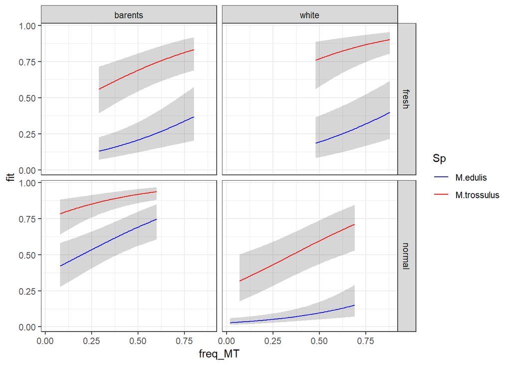

```r
logit_back <- function(x) exp(x)/(1 + exp(x)) # обратная логит-трансформация

## Пердсказания для фиксированной части модели
newdata <- myt2 %>% group_by(sea, sal_place2, Sp) %>% do(data.frame(freq_MT = seq(min(.$freq_MT), max(.$freq_MT), length.out = 100), size = mean(.$size)))

newdata$fit <- predict(Mod2, newdata = newdata, type = "response", re.form = NA)

newdata$fit_eta <- predict(Mod2, newdata = newdata, re.form = NA)


X <- model.matrix(~ Sp + sea + size + sal_place2 + freq_MT + Sp:sea + sea:size + sea:sal_place2, data = newdata)

b <- fixef(Mod2)

newdata$se_eta <- sqrt(diag(X %*% vcov(Mod2) %*% t(X)))

newdata$lwr <- logit_back(newdata$fit_eta - 2 * newdata$se_eta)
newdata$upr <- logit_back(newdata$fit_eta + 2 * newdata$se_eta)

ggplot(newdata, aes(x = freq_MT, y = fit)) + geom_ribbon(aes(ymin = lwr, ymax = upr, group = Sp), alpha = 0.2)  + geom_line(aes(color = Sp)) + facet_grid(sal_place2 ~ sea) + scale_color_manual(values = c("blue", "red")) + theme_bw()
```

Зная любовь ПП к приведению первичных данных на визуализациях модели, спешу отметить, что сделать это максимально первично нельзя, так как зависимая переменная имеет значения 1 или 0. В связи с этим в качестве отражения первичных данных (хотя и не лучшего из-за сильного варьирования объемов выборок) берем долю T-морфотипа среди MT и ME в каждом из локальных поселений (pop).

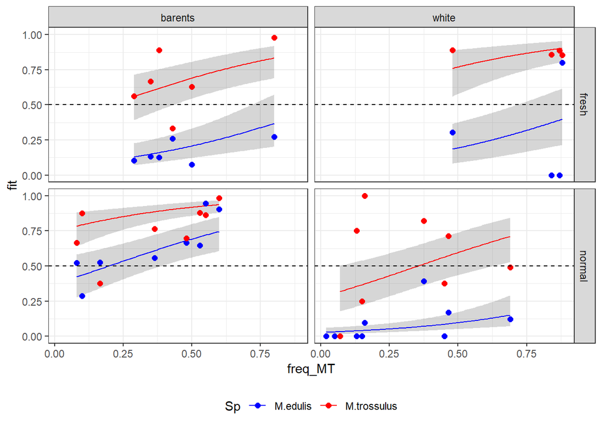

```r
library(doBy)
freq_T <- summaryBy(ind + freq_MT ~ Sp + pop + sea + sal_place2, data = myt2)



ggplot(newdata, aes(x = freq_MT, y = fit)) + geom_ribbon(aes(ymin = lwr, ymax = upr, group = Sp), alpha = 0.2)  + geom_line(aes(color = Sp)) + facet_grid(sal_place2 ~ sea) + scale_color_manual(values = c("blue", "red")) + geom_point(data = freq_T, aes(x = freq_MT.mean, y = ind.mean, color = Sp), size = 2) + theme_bw() + geom_hline(yintercept = 0.5, linetype = 2)+ theme(legend.position = "bottom")
```

Или, если хотите, вот так

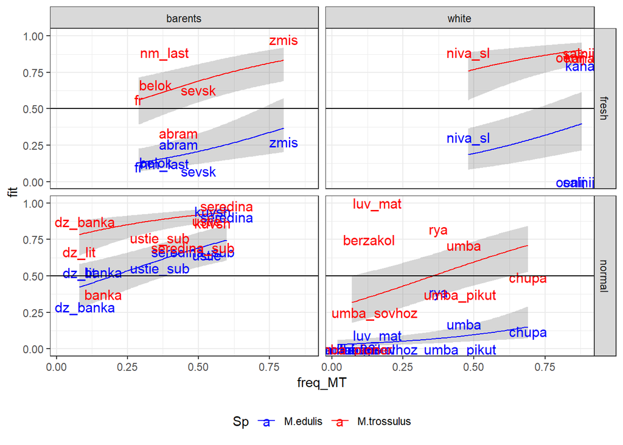

```r
ggplot(newdata, aes(x = freq_MT, y = fit)) + geom_ribbon(aes(ymin = lwr, ymax = upr, group = Sp), alpha = 0.2)  + geom_line(aes(color = Sp)) + facet_grid(sal_place2 ~ sea) + scale_color_manual(values = c("blue", "red")) + geom_text(data = freq_T, aes(x = freq_MT.mean, y = ind.mean, color = Sp, label = pop), size = 4) + theme_bw() + geom_hline(yintercept = 0.5, linetype = 1) + theme(legend.position = "bottom")
```

## К вопросу о размерах

Здесь придется за постоянную величину взять freq_MT. Лучше пусть это будет не среднее значение, а два значения: мало (0.25) и много (0.75).

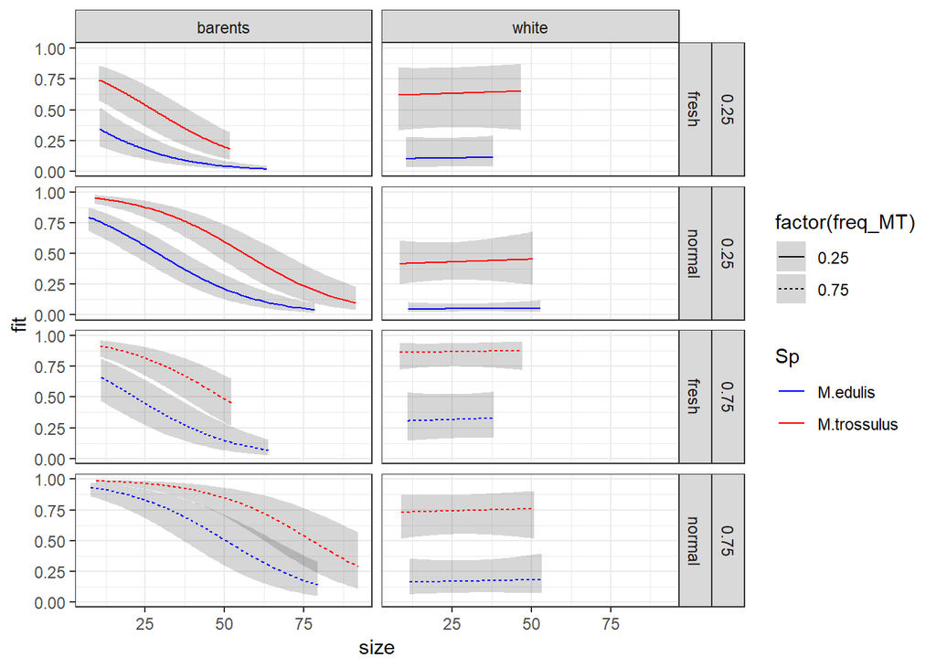

```r
myt2$freq_MT_class <- ifelse(myt2$freq_MT < 0.5, 0.25, 0.75)


newdata2 <- myt2 %>% group_by(sea, sal_place2, Sp, freq_MT_class) %>% do(data.frame(freq_MT = c(0.25, 0.75), size =seq(min(.$size), max(.$size), length.out = 100)))

newdata2$fit <- predict(Mod2, newdata = newdata2, type = "response", re.form = NA)

newdata2$fit_eta <- predict(Mod2, newdata = newdata2, re.form = NA)


X <- model.matrix(~  Sp + sea + size + sal_place2 + freq_MT + Sp:sea + sea:size + sea:sal_place2, data = newdata2)

b <- fixef(Mod2)

newdata2$se_eta <- sqrt(diag(X %*% vcov(Mod2) %*% t(X)))

newdata2$lwr <- logit_back(newdata2$fit_eta - 2 * newdata2$se_eta)
newdata2$upr <- logit_back(newdata2$fit_eta + 2 * newdata2$se_eta)

ggplot(newdata2, aes(x = size, y = fit, linetype = factor(freq_MT))) + geom_ribbon(aes(ymin = lwr, ymax = upr, group = Sp), alpha = 0.2)  + geom_line(aes(color = Sp)) + facet_grid(freq_MT ~ sal_place2 ~ sea) + scale_color_manual(values = c("blue", "red")) + theme_bw()
```

Как нанести сюда первичку не знаю, так как размер он ведь у каждой мидии, а она имеет по оси OY только значение 1 или 0. Могу посчитать доли каждом размерном классе. Получится вот так.

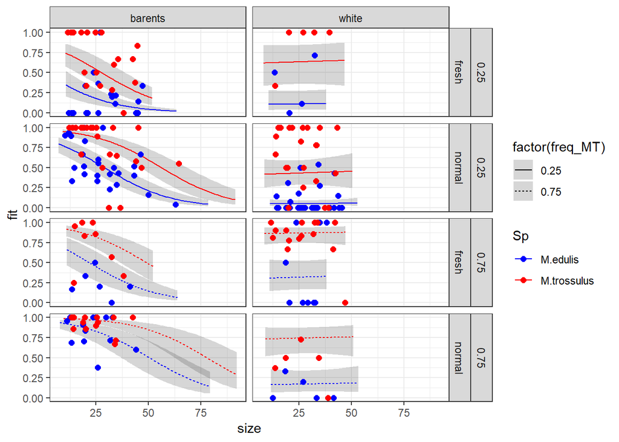

```r
size_classes <- ntile(myt2$size, n = 5)

myt2$size_classes <- size_classes

freq_T_size <- summaryBy(ind + size + freq_MT ~ Sp + pop + sea + sal_place2 + size_classes, data = myt2)

freq_T_size$freq_MT <- ifelse (freq_T_size$freq_MT.mean < 0.5, 0.25, 0.75)



ggplot(newdata2, aes(x = size, y = fit, linetype = factor(freq_MT))) + geom_ribbon(aes(ymin = lwr, ymax = upr, group = Sp), alpha = 0.2)  + geom_line(aes(color = Sp))  + scale_color_manual(values = c("blue", "red")) + theme_bw() +  geom_point(data = freq_T_size, aes(x = size.mean, y = ind.mean, color = Sp), size = 2) + facet_grid(freq_MT ~ sal_place2 ~ sea)
```

В тех выборках из Белого моря, которые использовали для построения данной модели (это ведь совсем не все выборки, которые были в работе Katolikova et al (2016)) связи с размером нет. Зато в Баренцевом море, чем больше размер, тем меньше вероятность встретить T-морфотип. По-моему, эта ровно так же, как было показано в Белом море.

## Итого

На вопрос №2 мы уже ответили. И в Белом и в Баренцевом морях чем больше в популяции MT тем больше там доля особей, имеющих T-морфотип.

На вопрос №3 Мы тоже отвечаем утвердительно. Несмотря на то, что есть взаимодействие факторов size и sea. Последнее вызвано тем, что в выборку по Белому морю были включены только такие выборки, где крупных моллюсков нет.

На вопрос №1. Скорее, тоже надо дать положительный ответ. Оно, конечно, взаимодействие факторов есть и, действительно, в Баренцевом море частота T-морфотипа среди MT меньше отличается от частоты этого морфотипа среди ME, нежели это наблюдается в Белом море. Однако все равно связь генетического статуса с язычком в двух морях однотипна - у MT частота T-морфотипа всегда выше. Кроме того, в опресненных местах в Баренцевом и Белом морях, согласно этой модели, все связи одинаковы. Отличия наблюдаются в не опресненных местах.